# 19 Dec

Anna Hutchinson

### Notation

$H$ denotes a hypothesis of association with T1D; $H=1$ indicates association, $H=0$ indicates no association (null hypothesis).

$$\begin{equation}
H \sim \text{Bernoulli}(\pi_1) \Longrightarrow P(H=1)=\pi_1
\end{equation}$$

$$\begin{equation}
\begin{split}
Q|H=0 \sim \text{Bernoulli}(q_0) & \Longrightarrow P(Q=1|H=0)=q_0 \\
& \Longrightarrow P(Q=0|H=0)=1-q_0
\end{split}
\end{equation}$$

$$\begin{equation}
P|H=0 \sim U(0,1)
\end{equation}$$

$$\begin{equation}
P \perp Q|H = 0
\end{equation}$$

$$\begin{equation}
\begin{split}
Q|H=1 \sim \text{Bernoulli}(q_1) & \Longrightarrow P(Q=1|H=1)=q_1 \\
& \Longrightarrow P(Q=0|H=1)=1-q_1
\end{split}
\end{equation}$$

$$\begin{equation}
f(P=p, Q=q|H_0)=f_0(p,q)
\end{equation}$$

$$\begin{equation}
f(P=p, Q=q|H_1)=f_1(p,q)
\end{equation}$$

$$\begin{equation}
f(P=p, Q=q)=f_0(p,q)(1-\pi_1)+f_1(p,q)\pi_1=f(p,q)
\end{equation}$$

### Method

#### 1. Generate the set of possible rejection regions.

Since $Q$ can only be 0 or 1, we just need two P value thresholds, $p_0$ for $Q=0$ and $p_1$ for $Q=1$.

$$\begin{equation}
L(p_0, p_1)=(P\leq p_0, Q=0) \cup (P\leq p_1, Q=1).
\end{equation}$$

#### 2. Pick the smallest rejection region that $(p[i], q[i])$ belongs.

Following on from our aim, we want the rejection region such that:

1. the probability of a null instance of $P,Q$ falling inside $L(p_0, p_1)$ is fixed at some value $\alpha$, that is

$$\begin{equation}
\int_{L(p_0, p_1)}df_0=\alpha
\end{equation}$$

2. the probability of a non-null instance of $P,Q$ falling inside $L(p_0, p_1)$ is maximal, that is

$$\begin{equation}
\int_{L(p_0, p_1)}df_1 \text{ is maximal}
\end{equation}$$

Previous works (e.g. appendix 8.1 in [James’ paper](https://www.biorxiv.org/content/10.1101/414318v3)) show that this optimal region is given by the set of points $\{(p,q):f_0(p,q)/f_1(p,q)\leq k_{\alpha}\}$ which means that in our case, the chosen $p_0$ and $p_1$ should satisfy

$$\begin{equation}
\dfrac{f_0(p_0,0)}{f(p_0,0)}=\dfrac{f_0(p_1,1)}{f(p_1,1)}
\end{equation}$$

using $f(p,q)=f_0(p,q)(1-\pi_1)+f_1(p,q)\pi_1$.

To find $p_0$ and $p_1$ that satisfy this equation, we derive an estimator of

$$\begin{equation}
\begin{split}
\dfrac{f_0(p,q)}{f(p,q)} &= \dfrac{f(P=p, Q=q|H_0)}{f(P=p, Q=q)}.
\end{split}
\end{equation}$$

Let

$$\begin{equation}
\begin{split}
\hat{h}(p,q) &= \dfrac{Pr(P\leq p, Q=q|H_0)}{Pr(P\leq p, Q=q)} \\[2ex]
& = \dfrac{Pr(P\leq p| Q=q, H_0)Pr(Q=q|H_0)}{Pr(P\leq p|Q=q)Pr(Q=q)} \\[2ex]
& \approx \dfrac{p\times Pr(Q=q|H_0)}{Pr(P\leq p|Q=q)Pr(Q=q)} \\[2ex]
& \approx \dfrac{p\times \color{red}{A(q)}}{\color{blue}{B(p, q)}/N}
\end{split}
\end{equation}$$

where $\color{red}{A(q)=\dfrac{\# \{Q=q, p>1/2\}}{\# \{p>1/2\}}}$ and $\color{blue}{B(p, q)=\# \{P\leq p, Q = q\}}$.

Thus we want to solve

$$\begin{equation}
\hat{h}(p_0,q = 0)=\hat{h}(p_1, q = 1)
\end{equation}$$

for $p_1$ if $q=0$ (set $p_0=p_i$) and for $p_0$ if $q=1$ (set $p_1=p_i$).

#### 3. Integrate the null distribution over this region to get $v$.

$$\begin{equation}
\begin{split}
\int_{L(p_0,p_1)}df_0 & = Pr(P,Q \in L(p_0, p_1)|H_0) \\
& = Pr((P\leq p_0, Q=0) \cup (P\leq p_1, Q=1) | H_0) \\
& = Pr(P\leq p_0, Q=0|H_0) + Pr(P\leq p_1, Q=1|H_1) \\
& = Pr(P\leq p_0|Q=0, H_0)Pr(Q=0|H_0) + Pr(P\leq p_1|Q=1, H_0)Pr(Q=1|H_0) \\
& = p_0\times (1-q_0) + p_1\times q_0
\end{split}
\end{equation}$$

where $q_0=A(1)$.

### Implementation

Begin by making a data frame with p = P value for association with T1D and q = binary active annotation indicator in thymus cells.

```
##             snps chr         p q
## 1 imm_7_50868985   7 0.7040051 0
## 2 imm_7_50869125   7 0.6381124 0
## 3 imm_7_50870347   7 0.2296590 0
## 4 imm_7_50870355   7 0.7335254 0
## 5 imm_7_50871208   7 0.9917130 0
## 6 imm_7_50871428   7 0.2443444 0
```

I first attempt to find the corresponding V value for the first $(p,q)$ pair. Note that I use a leave-one-chromosome-out method to account for LD.

```r
i <- 1

pi <- df$p[i]
qi <- df$q[i]

df_loo <- df[-which(df$chr == df[i, "chr"]), ] # df leave-one-out

A <- function(data, q){ # empirical estimate of P(Q = qi | H0)
  length(which(data$q == q & data$p > 0.5))/length(which(data$p > 0.5))
}

B <- function(data, p, q){ # numerator of empirical estimate of P(P < pi | Q = qi)
                           # as denominator cancels in h
  length(which(data$p <= p & data$q == q)) # to deal with smallest P vals
}
```

Since $qi=0$, I set $p_0=pi$ and find $p_1$ by solving

$$\begin{equation}
\begin{split}
\dfrac{p_0 A(0)}{B(p_0, q = 0)} &= \dfrac{p_1 A(1)}{B(p_1, q = 1)} \\[2ex]
\dfrac{p_0 A(0)}{A(1) B(p_0, q = 0)} &= \dfrac{p_1}{B(p_1, q = 1)}
\end{split}
\end{equation}$$

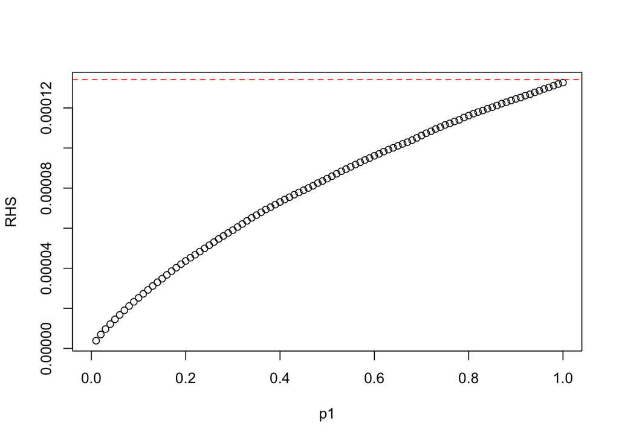

```r
q0 <- A(data = df_loo, q = 1)

p0 <- pi

LHS <- (p0 * A(df_loo, 0))/(A(df_loo, 1) * B(df_loo, p0, q = 0))

RHS <- function(data, p, q) p/length(which(data$p <= p & data$q == q))

x.test <- seq(0, 1, 0.01) # possible p1 values

RHS.test <- sapply(x.test, function(x) RHS(data = df_loo, p = x, q = 1))

plot(x.test, RHS.test, xlab = "p1", ylab = "RHS")
abline(h = LHS, col = 2, lty = 2)
```

So there is no solution to the equation… This happens for ~8% of $(p,q)$ pairs, all of which have large P values:

```
##    Min. 1st Qu.  Median    Mean 3rd Qu.    Max.
##  0.6299  0.7804  0.8505  0.8455  0.9148  0.9999
```

The summary of the $p_1$ values that are $>1$ are shown below:

```
##    Min. 1st Qu.  Median    Mean 3rd Qu.    Max.
##   1.000   1.057   1.110   1.110   1.159   1.274
```

**I’ve checked and there are no instances of $p_1$ or $p_0$ $<0$ and also no instances of $p_0>1$ when $qi=1$.**

For these data pairs, I use the `extendInt` parameter in the `uniroot` function and set the value for $p_1$ to 1.

```r
f <- function(data, c, p1, q) (p1/length(which(data$p <= p1 & data$q == q))) - c

epsilon <- 1e-35
p1 <- uniroot(f, c(0+epsilon, 1), data = df_loo, c = LHS, q = 1, extendInt = "yes")$root

p1
```

```
## [1] 1.011278
```

```r
p1 <- 1

v <- p0*(1-q0) + p1*q0

data.frame(p0, p1, q0, pi, qi, v)
```

```
##          p0 p1        q0        pi qi         v
## 1 0.7040051  1 0.4550499 0.7040051  0 0.8386976
```

### Implementation on whole data set

When I implement the method on the whole data set, I get errors for 78 rows. The distribution of P values for these 78 data pairs is shown below (i.e. the error occurs for very small P values):

```
##      Min.   1st Qu.    Median      Mean   3rd Qu.      Max.
## 0.000e+00 0.000e+00 0.000e+00 7.894e-37 3.000e-42 8.689e-36
```

I follow through an example where this error occurs and find that it is because $\color{blue}{B(p, q)=\# \{P\leq p, Q = q\}=0}$, i.e. there are no P values in the leave-one-chromosome-out data set that have a smaller P value. Thus, the denominator of a fraction is 0… not sure what to do about this… I remove these rows for now.

```r
error_index <- readRDS("error_index.RDS")
error_index1 <- readRDS("error_index1.RDS")

data <- readRDS("cFDR_data.RDS")

# p = pvals, q = active in thymus

df <- na.omit(data[,c("snps","chr","P","THYMUS")])

colnames(df)[c(3,4)] <- c("p","q")

df <- df[-error_index,]

v <- vector("numeric", dim(df)[1]) # prepare a container

cFDR <- for(i in 1:nrow(df)){
  tryCatch(
    expr = {
      pi <- df$p[i]
      qi <- df$q[i]

      df_loo <- df[-which(df$chr == df[i, "chr"]), ] # df leave-one-out

      q0 <- A(data = df_loo, 1)
      epsilon <- 1e-35

      if(qi == 0){

        p0 <- pi

        LHS <- (p0 * A(df_loo, 0))/(A(df_loo, 1) * B(df_loo, p0, q = 0))

        f <- function(data, c, p1, q) (p1/length(which(data$p <= p1 & data$q == q))) - c

        p1 <- uniroot(f, c(0+epsilon, 1), data = df_loo, c = LHS, q = 1, extendInt = "yes", maxiter = 5000)$root

        if(p1 > 1) p1 <- 1

      } else {

        p1 <- pi

        LHS <- (p1 * A(df_loo, 1))/(A(df_loo, 0) * B(df_loo, p1, q = 1))

        f <- function(data, c, p0, q) (p0/length(which(data$p <= p0 & data$q))) - c

        p0 <- uniroot(f, c(0 + epsilon, 1), data = df_loo, c = LHS, q = 0, extendInt = "yes", maxiter = 5000)$root

      }

      v[i] <- p0*(1-q0) + p1*q0

    },
    error = function(e){
      message("* Caught an error on itertion ", i)
            print(e)
    }
  )

}
```

```
FALSE <simpleError in uniroot(f, c(0 + epsilon, 1), data = df_loo, c = LHS, q = 0,     extendInt = "yes", maxiter = 5000): no sign change found in 5000 iterations>
FALSE <simpleError in uniroot(f, c(0 + epsilon, 1), data = df_loo, c = LHS, q = 0,     extendInt = "yes", maxiter = 5000): no sign change found in 5000 iterations>
FALSE <simpleError in uniroot(f, c(0 + epsilon, 1), data = df_loo, c = LHS, q = 1,     extendInt = "yes", maxiter = 5000): no sign change found in 5000 iterations>
```

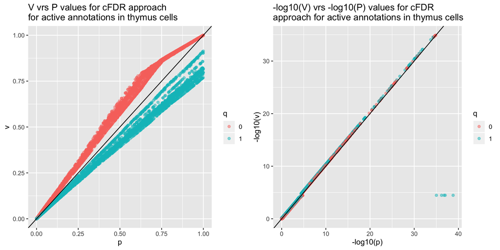

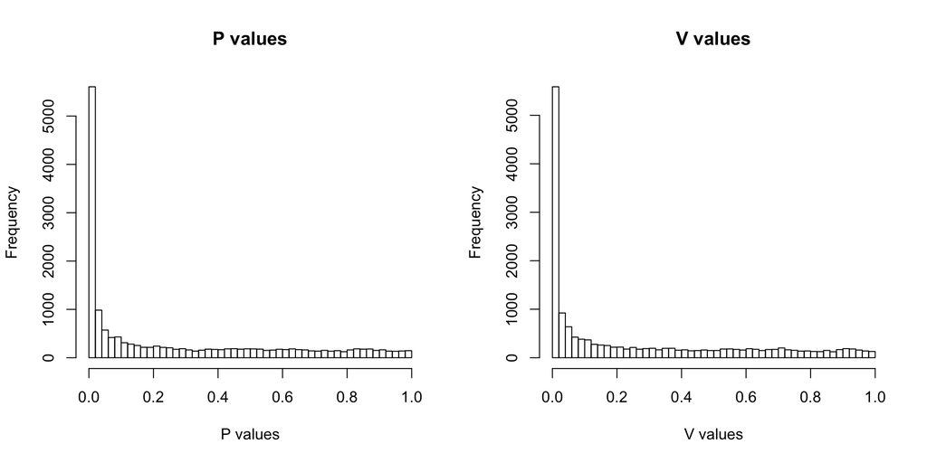

#### Comments

- Need to think of a better way to deal with no solution to the equation for large P values (rather than setting $p1=1$) as in the walkthrough example.
- Need to consider what to do for the lowest P values in the data set (so that $B(p, q)=\# \{P\leq p, Q = q\}=0$). Could set this to e.g. 1 instead of 0 (so we are not dividing by 0 in a fraction) but this doesn’t help with the RHS of the equation we are trying to solve..

```r
# what if there are no P values smaller than p?

B <- function(data, p, q){ # empirical estimate of P(P < pi | Q = qi)
  max(length(which(data$p <= p & data$q == q)), 1) # to deal with smallest P vals
}
```

- At the moment I’m setting `[0+epsilon, 1]` with `epsilon <- 1e-35` as the interval in the uniroot equation because there are no solutions to B for 0 (no P values less than 0). Note that this is why there are some blue values with very small P value and fixed V value.

#### Extra stuff before meeting

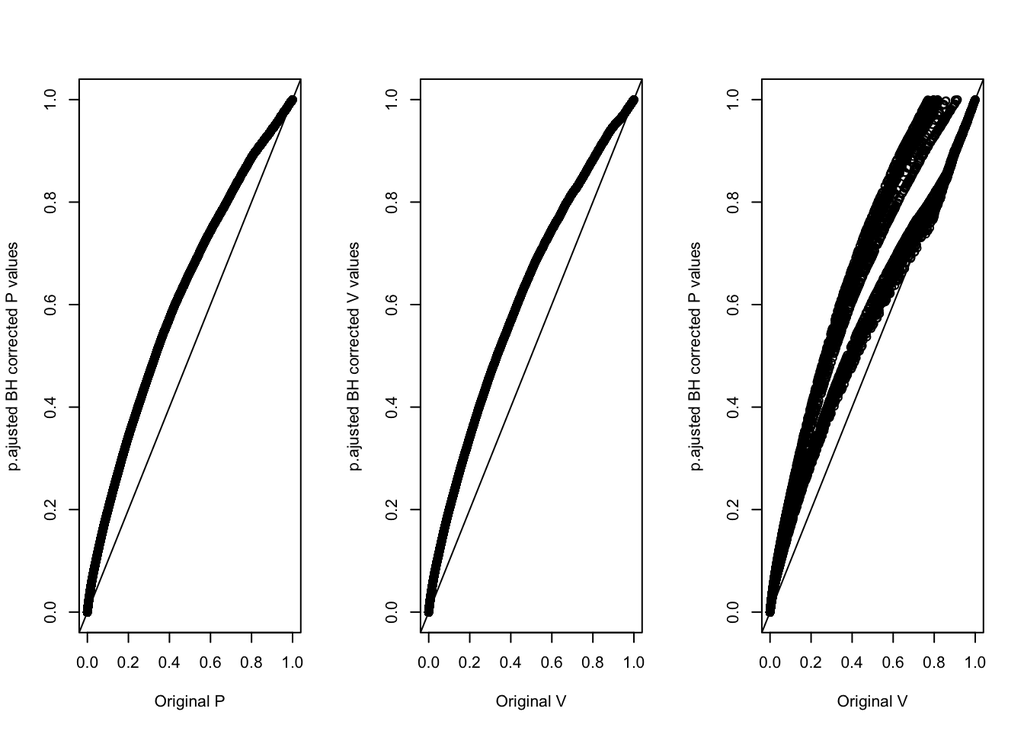

```r
plot_data <- cbind(df, v)

plot_data <- plot_data[-which(plot_data$v==0), ]

p_BH <- p.adjust(plot_data$p, method = "BH")

v_BH <- p.adjust(plot_data$v, method = "BH")

par(mfrow=c(1,3))

plot(plot_data$p, p_BH, xlab = "Original P", ylab = "p.ajusted BH corrected P values")
abline(a = 0, b = 1)

plot(plot_data$v, v_BH, xlab = "Original V", ylab = "p.ajusted BH corrected V values")
abline(a = 0, b = 1)

plot(plot_data$v, p_BH, xlab = "Original V", ylab = "p.ajusted BH corrected P values")
abline(a=0, b=1)
```

```r
###############

length(which(plot_data$p < 0.01))/dim(plot_data)[1] * 100 # 31.4% of original p values below threshold
```

```
## [1] 31.37723
```

```r
length(which(p_BH < 0.01))/length(p_BH) * 100 # 26.6% of BH adjusted p values below threshold
```

```
## [1] 26.64614
```

```r
length(which(plot_data$v < 0.01))/dim(plot_data)[1] * 100 # 31.2% of v values below threshold
```

```
## [1] 31.25785
```

```r
length(which(v_BH < 0.01))/length(v_BH) * 100 # 26.4% of BH adjusted v values below threshold
```

```
## [1] 26.44509
```

```r
###################

prop.table(table(plot_data[which(plot_data$p<0.01),"q"]))
```

```
##
##         0         1
## 0.4665599 0.5334401
```

```r
prop.table(table(plot_data[which(p_BH<0.01),"q"]))
```

```
##
##         0         1
## 0.4595614 0.5404386
```

```r
prop.table(table(plot_data[which(plot_data$v<0.01),"q"]))
```

```
##
##         0         1
## 0.4528643 0.5471357
```

```r
prop.table(table(plot_data[which(v_BH<0.01),"q"]))
```

```
##
##         0         1
## 0.4490378 0.5509622
```

```r
##################

prop.table(table(plot_data[which(plot_data$v<0.01 & plot_data$p<0.01),"q"]))
```

```
##
##         0         1
## 0.4582062 0.5417938
```

```r
prop.table(table(plot_data[which(v_BH<0.01 & p_BH<0.01),"q"]))
```

```
##
##         0         1
## 0.4519369 0.5480631
```